# FINARTS-CASE-1

2026-09-15

# Case 1: Comprehensive Financial Regression Analysis

Group 2:

- Chua, Erin Gabrielle
- Dilag, John Rey
- Siasoyco, Gabriel
- Singh, Gurmandeep

# Setup

Initialize packages.

```r
pacman::p_load(dplyr, ggplot2, quantmod, tidyverse, tidyquant, lubridate, timetk, zoo, car, sandwich, modelsummary, glmnet, MASS)

library(dplyr)
library(tidyr)
library(ggplot2)
library(lubridate)
library(broom)
library(car)
library(lmtest)
library(sandwich)
library(modelsummary)
library(glmnet)
library(MASS, exclude = "select")

set.seed(2026)
```

```r
# period start and end date constants
DATE_FROM <- as.Date("2014-12-01")
DATE_TO   <- as.Date("2025-12-31")
```

# 1. Data and Variables

We first need to build a dataset with the following information

1. Date - Year and Month
2. PLDT (TEL) - Monthly log returns
3. PSEi - Monthly log returns
4. CPI inflation - YoY % change
5. USD/PHP change - Monthly log change
6. BSP RRP rate change - Month-end first difference
7. Philippine 10Y government-yield change - Month-end first difference
8. M3 growth - YoY % growth
9. OFW remittance growth - YoY % growth
10. Manufacturing-production growth - YoY % growth
11. VIX - Monthly average

We can start by creating a dataframe to store all our necessary data to be exported as a CSV file later.

```r
full_data <- data.frame()
```

We first get the dates and the monthly PLDT returns, as well as the VIX monthly average through the quantmod package and adding the data to our full dataset.

```r
# helper function
get_month_end <- function(sym, name) {
  x <- getSymbols(sym, src = "yahoo", from = DATE_FROM, to = DATE_TO,
                  auto.assign = FALSE)
  m <- to.monthly(Ad(x), indexAt = "lastof", OHLC = FALSE)
  tibble(month = floor_date(index(m), "month"),
         !!name := as.numeric(m))
}

# PLDT
pldt  <- get_month_end("PHI", "TEL_px")

# VIX
getSymbols("VIXCLS", src = "FRED", from = DATE_FROM, to = DATE_TO)
```

```
## [1] "VIXCLS"
```

```r
vix <- apply.monthly(na.omit(VIXCLS), mean)
```

[output not shown]

```r
vix <- tibble(month = floor_date(index(vix), "month"),
              VIX = as.numeric(vix))

print(head(pldt, 5))
```

```
## # A tibble: 5 × 2
##   month      TEL_px
##   <date>      <dbl>
## 1 2014-12-01   31.3
## 2 2015-01-01   33.0
## 3 2015-02-01   35.5
## 4 2015-03-01   31.9
## 5 2015-04-01   32.8
```

```r
print(head(vix, 5))
```

```
## # A tibble: 5 × 2
##   month        VIX
##   <date>     <dbl>
## 1 2014-12-01  16.3
## 2 2015-01-01  19.1
## 3 2015-02-01  15.9
## 4 2015-03-01  14.8
## 5 2015-04-01  13.5
```

Now we add it to the corresponding columns.

```r
full_data <- pldt |>
  full_join(vix, by = "month") |>
  arrange(month) |>
  mutate(PLDT = log(TEL_px / dplyr::lag(TEL_px)))

head(full_data, 5)
```

```
## # A tibble: 5 × 4
##   month      TEL_px   VIX    PLDT
##   <date>      <dbl> <dbl>   <dbl>
## 1 2014-12-01   31.3  16.3 NA
## 2 2015-01-01   33.0  19.1  0.0525
## 3 2015-02-01   35.5  15.9  0.0709
## 4 2015-03-01   31.9  14.8 -0.107
## 5 2015-04-01   32.8  13.5  0.0307
```

Next we take needed regressors from our `/data` folder and clean it to be added to our full dataset alongside PLDT and VIX returns.

```r
psei <- read.csv("data/PSEi.csv") |>
  mutate(
    Date  = mdy(Date),
    Price = parse_number(Price)
  ) |>
  arrange(Date) |>
  group_by(month = floor_date(Date, "month")) |>
  summarise(PSEi_px = last(Price), .groups = "drop") |>
  mutate(PSEi = log(PSEi_px / dplyr::lag(PSEi_px)))

ph_cpi <- read_csv("data/PH_CPI.csv", show_col_types = FALSE) |>
  pivot_longer(-Year, names_to = "mon", values_to = "PH_CPI") |>
  mutate(month = ymd(paste(Year, mon, "01"), locale = "C")) |>
  arrange(month)

usd_php <- read_csv("data/USD_PHP.csv") |>
  mutate(
    month = make_date(year, match(month, month.name), 1)
  ) |>
  arrange(month) |>
  transmute(
    month,
    USD_PHP_px = end_of_period,
    USD_PHP    = log(USD_PHP_px / dplyr::lag(USD_PHP_px))
  )
full_data <- full_data |>
    left_join(usd_php |> dplyr::select(month, USD_PHP_px, USD_PHP), by = "month") |>
            mutate(
              TEL_php = TEL_px * USD_PHP_px,
              PLDT    = log(TEL_php / dplyr::lag(TEL_php))
            )

bsp_rrp <- read.csv("data/BSP_RRP_Rate.csv") |>
  mutate(
    month = ymd(month)
  ) |>
  arrange(month) |>
  mutate (
    BSP_RRP_Rate = value - lag(value)
  )

ph_10y <- read.csv("data/PH_10Y_GS_Yield.csv") |>
  mutate(
    month = mdy(trimws(Month))
  ) |>
  arrange(month) |>
  mutate(
    PH_10Y_GS_Yield = Price - lag(Price)
  )

m3 <- read.csv("data/PH_M3.csv") |>
  mutate(
    month = dmy(trimws(Date))
  ) |>
  arrange (month) |>
  rename(PH_M3 = Close)

ofwr <- read.csv("data/PH_OFW_Remittances.csv") |>
  mutate (
    month = make_date(year, match(month, month.name), 1)
  ) |>
  arrange(month) |>
  rename(PH_OFW_Remittances = Monthly)

ph_manufacturing <- read.csv("data/PH_Manufacturing_Production.csv") |>
  mutate(
    month = ymd(Date)
  ) |>
  arrange(month) |>
  rename(PH_Manufacturing_Production = Value)
```

Now we can join all our data to the full dataset using left joins on the date.

```r
full_data <- full_data |>
  filter(month >= as.Date("2018-01-01"),
         month <= as.Date(DATE_TO)) |>
  left_join(psei |> dplyr::select(month, PSEi), by = "month") |>
  left_join(ph_cpi |> dplyr::select(month, PH_CPI), by = "month") |>
  left_join(bsp_rrp |> dplyr::select(month, BSP_RRP_Rate), by = "month") |>
  left_join(ph_10y |> dplyr::select(month, PH_10Y_GS_Yield), by = "month") |>
  left_join(m3 |> dplyr::select(month, PH_M3), by = "month") |>
  left_join(ofwr |> dplyr::select(month, PH_OFW_Remittances), by = "month") |>
  left_join(ph_manufacturing |> dplyr::select(month, PH_Manufacturing_Production), by = "month") |>
  dplyr::select(-c(TEL_px, TEL_php, USD_PHP_px))

head(full_data, 10)
```

```
## # A tibble: 10 × 11
##    month        VIX     PLDT  USD_PHP    PSEi PH_CPI BSP_RRP_Rate
##    <date>     <dbl>    <dbl>    <dbl>   <dbl>  <dbl>        <dbl>
##  1 2018-01-01  11.1  0.0451   0.0296   0.0237    3.4         0
##  2 2018-02-01  22.5 -0.0437   0.0119  -0.0335    3.7         0
##  3 2018-03-01  19.0 -0.0152   0.00332 -0.0602    4.3         0
##  4 2018-04-01  18.3 -0.0176  -0.00465 -0.0203    4.3         0
##  5 2018-05-01  14.1 -0.115    0.0138  -0.0421    4.6         0.25
##  6 2018-06-01  13.7 -0.0171   0.0157  -0.0413    5           0.25
##  7 2018-07-01  13.1  0.0613  -0.00485  0.0644    5.8         0
##  8 2018-08-01  12.5  0.0517   0.00321  0.0237    6.6         0.5
##  9 2018-09-01  12.9 -0.00486  0.0152  -0.0765    6.9         0.5
## 10 2018-10-01  19.4 -0.0229  -0.0120  -0.0189    6.9         0
## # ℹ 4 more variables: PH_10Y_GS_Yield <dbl>, PH_M3 <dbl>,
## #   PH_OFW_Remittances <dbl>, PH_Manufacturing_Production <dbl>
```

```r
write.csv(full_data, "data/fulldata.csv", row.names = FALSE)
```

## Descriptive Statistics

We can check our full dataset and interpret/check for scale, skewness, extreme values, and data problems

```r
datasummary_skim(full_data |> dplyr::select(-month))
```

Unique

Missing Pct.

Mean

SD

Min

Median

Max

Histogram

VIX

96

0

19.7

6.8

11.1

18.3

57.7

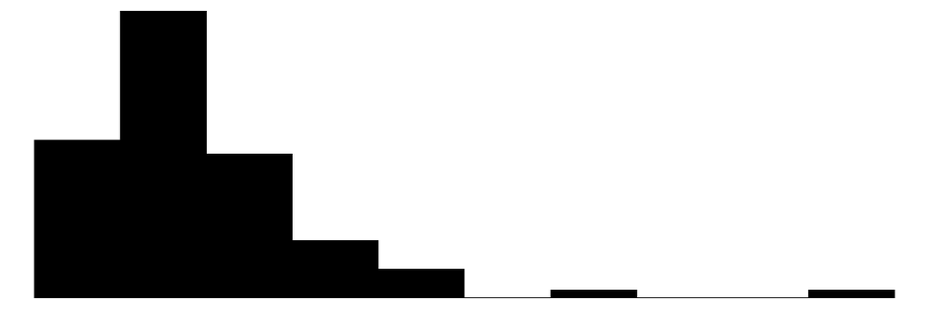

PLDT

96

0

0.0

0.1

-0.3

0.0

0.2

[figure not shown]

USD_PHP

96

0

0.0

0.0

-0.0

0.0

0.1

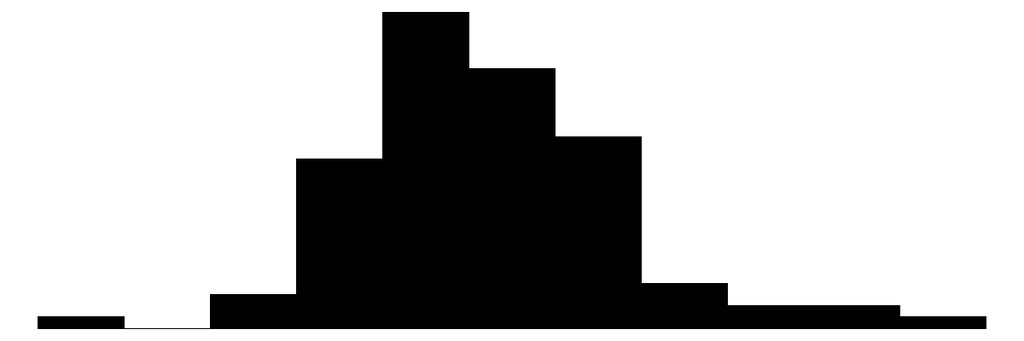

PSEi

96

0

-0.0

0.1

-0.2

0.0

0.1

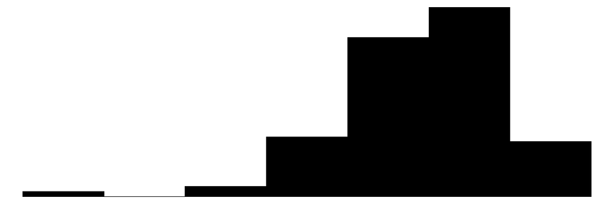

PH_CPI

51

0

3.8

1.9

0.5

3.7

8.7

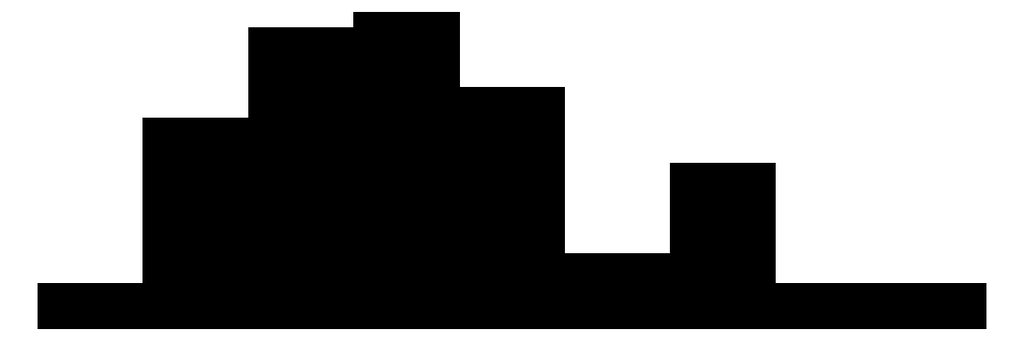

BSP_RRP_Rate

6

0

0.0

0.2

-0.5

0.0

0.8

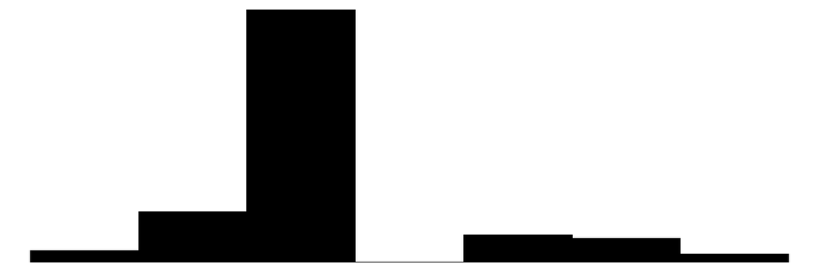

PH_10Y_GS_Yield

95

0

0.0

0.4

-1.6

0.0

0.9

[figure not shown]

PH_M3

95

0

6.6

6.5

-8.5

6.1

22.6

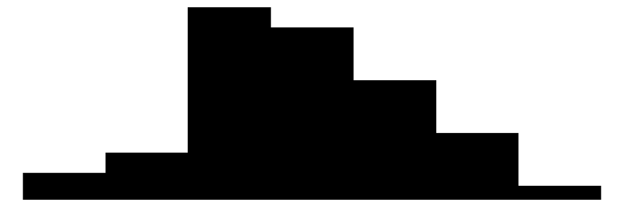

PH_OFW_Remittances

58

0

3.1

4.5

-19.3

3.2

13.1

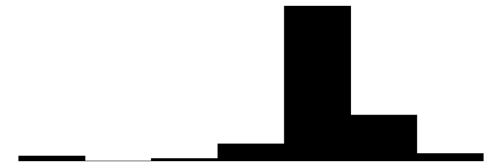

PH_Manufacturing_Production

93

0

20.9

103.3

-82.2

1.5

534.4

[figure not shown]

All 10 variables have 0% missing values across the full dataset, yielding a core sample size of $n = 96$ observations (spanning 8 years of monthly data).

The market return and exchange rate variables (`PLDT`, `PSEi`, and `USD_PHP`) display means and medians centered near $0.0$, with standard deviations ranging between $0.0$ and $0.1$. This behavior confirms that log-transformed returns exhibit stationary/statioc behavior for our linear modelling.

Risk and policy rate indicators show more distinct distributional characteristics. The interest rate change variables (`BSP_RRP_Rate` and `PH_10Y_GS_Yield`) center near a mean and median of $0.0$ but exhibit higher satndard deviation ($\text{SD} = 0.2$ and $0.4$, respectively) possibly due to policy changes and market volatility. In contrast, the `VIX` operates on an index level with a mean of $19.7$ and median of $18.3$, displaying strong positive right-skewness ($\text{Max} = 57.7$) that can reflect sharp global market crisis spikes.

Macroeconomic growth indicators (`PH_CPI`, `PH_M3`, and `PH_OFW_Remittances`) reflect real life economic shifts, with YoY inflation averaging $3.8\%$ and remittance growth averaging $3.1\%$. However, `PH_Manufacturing_Production` presents as a clear outlier relative to all other regressors. While its median growth is modest ($1.5\%$), its mean jumps to $20.9\%$ with an extreme standard deviation of $103.3\%$ and a peak maximum of $534.4\%$. This severe skew could possibly stem from pandemic/post-pandemic effects, thus providing a justification for testing robust regression techniques (e.g., Huber M-estimation) in later steps.

## Visualizations

To get a better picture of our data, we perform data visualization to help see data points and relations better.

**Monthly PLDT log returns**

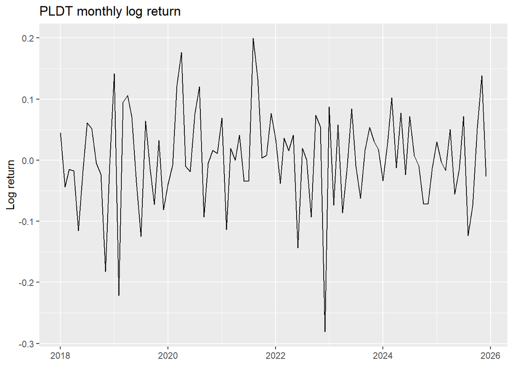

```r
ggplot(full_data, aes(month, PLDT)) +
  geom_line() +
  labs(title = "PLDT monthly log return", x = NULL, y = "Log return")
```

We can see that the values hovers around zero with no trend. Swings are relatively large (about -0.27 to +0.20), and there’s a big drop around late 2022 and a big gain around mid-2021. These highs and lows show historical events that affect returns, because in late 2022 PLDT Inc. experienced a major corporate crisis driven by a massive ₱48-billion capital expenditure budget overrun (https://insiderph.com/case-closed-pldt-settles-p167-m-budget-overrun-lawsuit-in-california-court). While in mid-2021 PLDT reported having record-breaking financial figures and massive fiber network expansion due to pandemic-era remote work and online learning(https://www.rappler.com/business/pldt-earnings-report-january-december-2021/).

**Distribution of PLDT monthly log return**

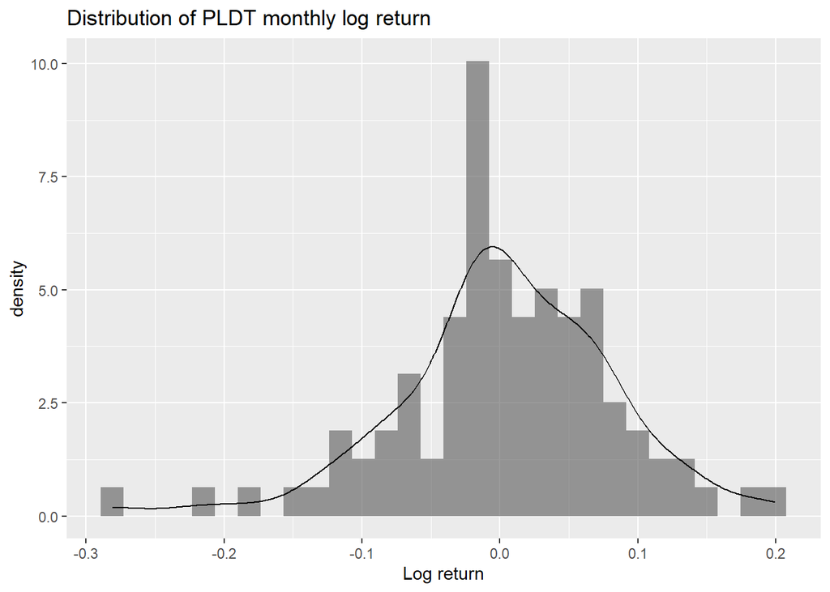

```r
ggplot(full_data, aes(PLDT)) +
  geom_histogram(aes(y = after_stat(density)), bins = 30, alpha = .6) +
  geom_density() +
  labs(title = "Distribution of PLDT monthly log return", x = "Log return")
```

The histogram shown is roughly bell-shaped but with a heavier left tail (implying that several months have returns below -0.15).

**PLDT returns vs. candidate regressors**

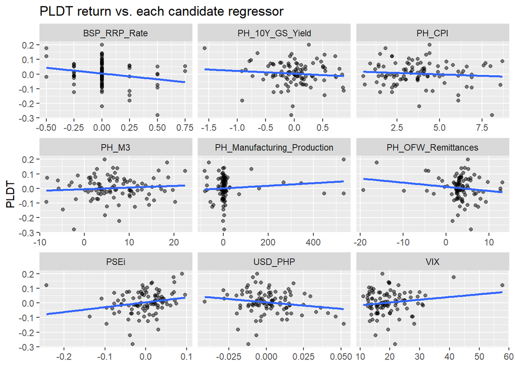

```r
full_data |>
  pivot_longer(-c(month, PLDT), names_to = "var", values_to = "x") |>
  ggplot(aes(x, PLDT)) +
  geom_point(alpha = .5) +
  geom_smooth(method = "lm", se = FALSE) +
  facet_wrap(~ var, scales = "free_x") +
  labs(title = "PLDT return vs. each candidate regressor", x = NULL)
```

There were some interesting scatterplot observations, where we evaluate best fit between each regressor against PLDT returns:

- PSEi slopes up and USD_PHP slopes down. This implies that in months where PSEi was higher, PLDT returns were higher. While in months when the peso weakened more, PLDT’s return tended to be lower.
- BSP_RRP_Rate, PH_10Y_GS_Yield, and PH_OFW_Remittances show a slight downward slope, implying that higher interest rates, government yields, or remittance growths slightly coincide with lower PLDT returns. On the other hand PH_M3 and PH_Manufacturing_Production show slight upward slopes indicating minor positive co-movement with PLDT returns
- VIX Shows a slight positive trend, indicating higher global market volatility weakly correlates with higher PLDT returns.

# 2. Initial Regression Model

Next we have an initial regression model, we use Multiple Linear Regression (MLR) because our dependent variable (PLDT log returns) depends on multiple independent variables as mentioned above. We use the following formula:
$$\begin{aligned}
PLDT_i
&= \beta_0 +
\beta_1\, PSEi_i +
\beta_2\, USD/PHP_i +
\beta_3\, \text{BSP RRP Rate}_i + \\
&\beta_4\, CPI_i +
\beta_5\, \text{10Y Govt. Yield Change}_i +
\beta_6\, \text{M3 Growth}_i + \\
&\beta_7\, \text{OFW Remittance Growth}_i +
\beta_8\, \text{Manufacturing Production Growth}_i + \\
&\beta_9\, \text{VIX}_i +
\varepsilon_i\\[6pt]
\end{aligned}$$

For this section, we have the following null and alternative hypothesis at $\alpha = 0.05$
$$\begin{aligned}
H_0&: \beta_j = 0 \\
H_1&: \beta_j \neq 0
\\
\text{Where:}\\
&\beta = \text{A regressor coefficient}\\
&j = 1, 2, \dots, 9 \text{ (regressor index)}\\
\end{aligned}$$

## Estimation

Here we use `lm()` to fit a linear regression model on our data and `summary()` acts as a diagnostic report evaluating the fit, coefficients, and statistical significance of the regression model.

```r
m_full <- lm(
  PLDT ~ PSEi + PH_CPI + USD_PHP + BSP_RRP_Rate + PH_10Y_GS_Yield +
    PH_M3 + PH_OFW_Remittances + PH_Manufacturing_Production + VIX,
  data = full_data
)

summary(m_full)
```

```
##
## Call:
## lm(formula = PLDT ~ PSEi + PH_CPI + USD_PHP + BSP_RRP_Rate +
##     PH_10Y_GS_Yield + PH_M3 + PH_OFW_Remittances + PH_Manufacturing_Production +
##     VIX, data = full_data)
##
## Residuals:
##       Min        1Q    Median        3Q       Max
## -0.246572 -0.041134 -0.004653  0.057479  0.132447
##
## Coefficients:
##                               Estimate Std. Error t value Pr(>|t|)
## (Intercept)                 -1.221e-02  3.874e-02  -0.315   0.7534
## PSEi                         3.290e-01  1.818e-01   1.810   0.0738 .
## PH_CPI                       1.012e-03  6.174e-03   0.164   0.8702
## USD_PHP                     -5.593e-01  6.026e-01  -0.928   0.3560
## BSP_RRP_Rate                -7.872e-02  5.034e-02  -1.564   0.1216
## PH_10Y_GS_Yield              9.113e-03  2.176e-02   0.419   0.6764
## PH_M3                       -6.813e-04  1.619e-03  -0.421   0.6750
## PH_OFW_Remittances          -3.154e-03  2.009e-03  -1.570   0.1200
## PH_Manufacturing_Production  1.284e-04  8.001e-05   1.605   0.1121
## VIX                          1.347e-03  1.311e-03   1.028   0.3069
## ---
## Signif. codes:  0 '***' 0.001 '**' 0.01 '*' 0.05 '.' 0.1 ' ' 1
##
## Residual standard error: 0.07628 on 86 degrees of freedom
## Multiple R-squared:  0.1676, Adjusted R-squared:  0.08053
## F-statistic: 1.925 on 9 and 86 DF,  p-value: 0.05887
```

First, we see here that there us an adjusted R-squared of $0.08053$ (or $8.053%$), meaning that 9 regressors combined only explain $8.053%$ of the variation in PLDT returns, while the remaining $~92%$ is influenced by other factors not captured by the model. Next, looking at the p-value of $0.05887$, we see that it is only slightly above the standard $0.05$ threshold, further showing that the model is only somewhat significant. Therefore we fail to reject the null hypothesis.

Looking at the `Pr(>|t|)` column, we see that the p-values for each individual regressor, almost all of them have values well above $0.05$, meaning they are statistically insignificant individually. `PSEi` has the strongest relationship in the model. A 1-unit increase in `PSEi` returns is associated with a $~0.33$ increase in `PLDT` returns, because its p-value is under $0.10$, it is marginally significant at the 10% level.

While variables like `PH_CPI`, `USD_PHP`, `BSP_RRP_Rate`, `PH_10Y_GS_Yield`, `PH_M3`, `PH_OFW_Remittances`, `PH_Manufacturing_Production`, and `VIX` all have high p-values ($> 0.10$), having no statistical significant over `PLDT`’s returns when accounting for other regressors due to its low coefficient values.

## Coefficient interpretation

Using the estimated parameters from our multiple linear regression model (`m_full`), we interpret the marginal effect of each regressor by holding all other variables constant:

- **Intercept ($\hat{\beta}_0 = -0.0122$):** When all independent variables are set to zero, the expected monthly log return of PLDT is $-1.22\%$.
- **PSEi Market Return ($\hat{\beta}_1 = 0.3290, p = 0.0738$):** Holding all macroeconomic and global factors constant, a $1.00$ unit ($100\%$) increase in the PSEi log return is associated with a $0.3290$ ($+32.90$ percentage points) increase in PLDT’s log return. This implies a stock beta relative to the local market of roughly $0.33$, and it is statistically significant at the $10\%$ level.
- **USD/PHP Exchange Rate Change ($\hat{\beta}_3 = -0.5593, p = 0.3560$):** Holding other variables constant, a $1.00$ unit increase in the USD/PHP monthly log change is associated with a $-0.5593$ change in PLDT returns. While this makes sense from an economical standpoint (as depreciation increases foreign debt burden or import costs), the relationship is statistically insignificant ($p > 0.10$).
- **BSP Policy Rate Change ($\hat{\beta}_4 = -0.0787, p = 0.1216$):** Holding other variables constant, a $1\%$ rate hike by the central bank is associated with a $-0.0787$ change in PLDT returns.
- **VIX Volatility Index ($\hat{\beta}_9 = 0.0014, p = 0.3069$):** Holding other variables constant, a $1$-unit increase in global market volatility (VIX) is associated with a $0.0014$ change in PLDT returns.
- **Other Macroeconomic Variables (`PH_CPI`, `PH_10Y_GS_Yield`, `PH_M3`, `PH_OFW_Remittances`, `PH_Manufacturing_Production`):** Each of their respective coefficients represents the expected change in PLDT returns per 1-unit change in that macroeconomic indicator, holding all else constant. However, because their $p$-values exceed $0.10$, we conclude that these individual marginal effects are not statistically distinguishable from zero.

# 3. Statistical Inference

## Individual T-Tests

We perform individual two-tailed $t$-tests for each regression parameter, testing the null hypothesis $H_0: \beta_k = 0$ against the alternative hypothesis $H_a: \beta_k \neq 0$ at a $5\%$ significance level ($\alpha = 0.05$).

```r
t_tests <- broom::tidy(m_full) |>
  dplyr::filter(term != "(Intercept)") |>
  dplyr::mutate(
    decision = ifelse(p.value < 0.05, "Reject H0", "Fail to reject H0")
  )

knitr::kable(t_tests, digits = 4,
             col.names = c("Variable", "Estimate", "Std. Error", "t", "p-value", "Decision (5%)"))
```

| Variable | Estimate | Std. Error | t | p-value | Decision (5%) |
| --- | --- | --- | --- | --- | --- |
| PSEi | 0.3290 | 0.1818 | 1.8097 | 0.0738 | Fail to reject H0 |
| PH_CPI | 0.0010 | 0.0062 | 0.1639 | 0.8702 | Fail to reject H0 |
| USD_PHP | -0.5593 | 0.6026 | -0.9281 | 0.3560 | Fail to reject H0 |
| BSP_RRP_Rate | -0.0787 | 0.0503 | -1.5636 | 0.1216 | Fail to reject H0 |
| PH_10Y_GS_Yield | 0.0091 | 0.0218 | 0.4188 | 0.6764 | Fail to reject H0 |
| PH_M3 | -0.0007 | 0.0016 | -0.4208 | 0.6750 | Fail to reject H0 |
| PH_OFW_Remittances | -0.0032 | 0.0020 | -1.5702 | 0.1200 | Fail to reject H0 |
| PH_Manufacturing_Production | 0.0001 | 0.0001 | 1.6052 | 0.1121 | Fail to reject H0 |
| VIX | 0.0013 | 0.0013 | 1.0279 | 0.3069 | Fail to reject H0 |

```r
qt(0.975, df.residual(m_full))
```

```
## [1] 1.987934
```

- **PSEi Market Return ($p = 0.0738$):** The local stock market index yields a $t$-statistic of $1.8097$. While this falls just short of the strict 5% significance threshold (hence coded as “Fail to reject $H_0$” at $\alpha = 0.05$), it is **statistically significant at the 10% significance level** ($p < 0.10$). Its positive estimate ($0.3290$) confirms that broader market movements represent PLDT’s primary systematic risk influence.
- **All Macroeconomic and Global Risk Regressors:** Variables such as inflation (`PH_CPI`, $p = 0.8702$), exchange rate changes (`USD_PHP`, $p = 0.3560$), policy rates (`BSP_RRP_Rate`, $p = 0.1216$), and global volatility (`VIX`, $p = 0.3069$) all yield p-values well above the $0.05$ (and $0.10$) thresholds.
- **Conclusion on Individual Significance:** Because their confidence intervals include zero and their p-values exceed standard significance levels, we fail to reject the null hypothesis for these macroeconomic variables. Individually, they do not exhibit statistically robust linear relationships with `PLDT`’s returns in this full OLS specification, likely due to multicollinearity, shared variance, or noise in monthly macroeconomic releases.

## Confidence Intervals

The `confint()` function calculates the 95% confidence interval for each parameter in the regression model.

```r
confint(m_full)
```

```
##                                     2.5 %       97.5 %
## (Intercept)                 -8.922432e-02 0.0648035153
## PSEi                        -3.241496e-02 0.6904908441
## PH_CPI                      -1.126140e-02 0.0132851795
## USD_PHP                     -1.757197e+00 0.6386834494
## BSP_RRP_Rate                -1.787921e-01 0.0213608686
## PH_10Y_GS_Yield             -3.414456e-02 0.0523703221
## PH_M3                       -3.900226e-03 0.0025375180
## PH_OFW_Remittances          -7.147411e-03 0.0008391352
## PH_Manufacturing_Production -3.062161e-05 0.0002874946
## VIX                         -1.258462e-03 0.0039531461
```

The 95% confidence intervals provide a range of plausible values for each population regression coefficient. We see that each single interval contains zero (e.g., `PSEi` ranges from $-0.0324$ to $+0.6905$; USD/PHP ranges from $-1.7572$ to $+0.6387$). Because zero is included within the 95% confidence interval for all parameters, this confirms that we fail to reject the null hypothesis at the 5% significance level for each individual regressor, aligning with our t-test p-values.

## Joint Significance (F-Test)

To test whether the explanatory variables have joint explanatory power over `PLDT`’s returns, we examine two $F$-tests.

```r
f <- summary(m_full)$fstatistic
f
```

```
##     value     numdf     dendf
##  1.924549  9.000000 86.000000
```

```r
pf(f[1], f[2], f[3], lower.tail = FALSE)
```

```
##      value
## 0.05886847
```

```r
car::linearHypothesis(m_full, c(
  "PH_CPI = 0", "USD_PHP = 0", "BSP_RRP_Rate = 0", "PH_10Y_GS_Yield = 0",
  "PH_M3 = 0", "PH_OFW_Remittances = 0", "PH_Manufacturing_Production = 0", "VIX = 0"
))
```

```
##
## Linear hypothesis test:
## PH_CPI = 0
## USD_PHP = 0
## BSP_RRP_Rate = 0
## PH_10Y_GS_Yield = 0
## PH_M3 = 0
## PH_OFW_Remittances = 0
## PH_Manufacturing_Production = 0
## VIX = 0
##
## Model 1: restricted model
## Model 2: PLDT ~ PSEi + PH_CPI + USD_PHP + BSP_RRP_Rate + PH_10Y_GS_Yield +
##     PH_M3 + PH_OFW_Remittances + PH_Manufacturing_Production +
##     VIX
##
##   Res.Df     RSS Df Sum of Sq      F Pr(>F)
## 1     94 0.57286
## 2     86 0.50043  8  0.072432 1.5559 0.1502
```

The overall model $F$-test yields an $F$-statistic of $1.9246$ ($p = 0.0589$), allowing us to reject the null hypothesis of joint zero slopes at the $10\%$ significance level. However, a restricted linear hypothesis test examining the block of macroeconomic and risk variables jointly yields $F = 1.5559$ ($p = 0.1502$), indicating that these macro variables as a group do not achieve joint statistical significance at standard levels.

## Economic Significance

While individual $t$-tests measure statistical significance, economic significance evaluates the real-world magnitude of a 1-standard deviation ($\text{SD}$) shock in each regressor on PLDT’s returns.

```r
sds <- sapply(full_data[names(coef(m_full))[-1]], sd)
econ <- data.frame(
  variable = names(sds),
  effect_per_1sd = round(coef(m_full)[-1] * sds, 4)
)
econ
```

```
##                                                variable effect_per_1sd
## PSEi                                               PSEi         0.0170
## PH_CPI                                           PH_CPI         0.0019
## USD_PHP                                         USD_PHP        -0.0088
## BSP_RRP_Rate                               BSP_RRP_Rate        -0.0173
## PH_10Y_GS_Yield                         PH_10Y_GS_Yield         0.0039
## PH_M3                                             PH_M3        -0.0044
## PH_OFW_Remittances                   PH_OFW_Remittances        -0.0142
## PH_Manufacturing_Production PH_Manufacturing_Production         0.0133
## VIX                                                 VIX         0.0091
```

The results show that the `PSEi` market return exerts the largest positive economic impact ($+0.0170$ or $+1.70$ percentage points per 1-SD change), followed closely by `PH_Manufacturing_Production` ($+0.0133$). A 1-SD increase in the `BSP_RRP_Rate` ($-0.0173$) and `PH_OFW_Remittances` ($-0.0142$) exerts the largest downward economic pressures on `PLDT` returns, demonstrating that economic magnitude can remain substantial even when coefficients carry higher standard errors.

# 4. Model Evaluation and Comparison

Next we compare our intitial model (`m_full`) against 2 other models, * `m_market` is a “market-only model” (mirroring a CAPM framework), which uses only the local stock market index (`PSEi`) to explain `PLDT`’s returns. * `m_macro` is a “macro-only model”, which incorporates all macroeconomic indicators, monetary policy variables, and global risk factors (`VIX`) while excluding the stock market index. * `m_full` is our full model that combines both market risk and macroeconomic/global indicators.

```r
full_data_clean <- model.frame(m_full)

m_market <- lm(PLDT ~ PSEi, data = full_data)
m_macro  <- lm(PLDT ~ PH_CPI + USD_PHP + BSP_RRP_Rate + PH_10Y_GS_Yield +
                 PH_M3 + PH_OFW_Remittances + PH_Manufacturing_Production + VIX,
               data = full_data)

modelsummary(
  list("Market only" = m_market, "Macro only" = m_macro, "Full" = m_full),
  stars = TRUE, gof_omit = "Log.Lik|RMSE"
)
```

|  | Market only | Macro only | Full |
| --- | --- | --- | --- |
| (Intercept) | 0.004 | -0.006 | -0.012 |
|  | (0.008) | (0.039) | (0.039) |
| PSEi | 0.334* |  | 0.329+ |
|  | (0.155) |  | (0.182) |
| PH_CPI |  | 0.001 | 0.001 |
|  |  | (0.006) | (0.006) |
| USD_PHP |  | -0.963+ | -0.559 |
|  |  | (0.567) | (0.603) |
| BSP_RRP_Rate |  | -0.078 | -0.079 |
|  |  | (0.051) | (0.050) |
| PH_10Y_GS_Yield |  | -0.003 | 0.009 |
|  |  | (0.021) | (0.022) |
| PH_M3 |  | -0.001 | -0.001 |
|  |  | (0.002) | (0.002) |
| PH_OFW_Remittances |  | -0.003 | -0.003 |
|  |  | (0.002) | (0.002) |
| PH_Manufacturing_Production |  | 0.000+ | 0.000 |
|  |  | (0.000) | (0.000) |
| VIX |  | 0.001 | 0.001 |
|  |  | (0.001) | (0.001) |
| Num.Obs. | 96 | 96 | 96 |
| R2 | 0.047 | 0.136 | 0.168 |
| R2 Adj. | 0.037 | 0.056 | 0.081 |
| AIC | -213.2 | -208.6 | -210.2 |
| BIC | -205.5 | -183.0 | -182.0 |
| F | 4.653 | 1.711 | 1.925 |

+ p < 0.1, * p < 0.05, ** p < 0.01, *** p < 0.001

```r
AIC(m_market, m_macro, m_full)
```

```
##          df       AIC
## m_market  3 -213.2235
## m_macro  10 -208.6127
## m_full   11 -210.2004
```

```r
BIC(m_market, m_macro, m_full)
```

```
##          df       BIC
## m_market  3 -205.5304
## m_macro  10 -182.9692
## m_full   11 -181.9926
```

```r
anova(m_market, m_full)
```

```
## Analysis of Variance Table
##
## Model 1: PLDT ~ PSEi
## Model 2: PLDT ~ PSEi + PH_CPI + USD_PHP + BSP_RRP_Rate + PH_10Y_GS_Yield +
##     PH_M3 + PH_OFW_Remittances + PH_Manufacturing_Production +
##     VIX
##   Res.Df     RSS Df Sum of Sq      F Pr(>F)
## 1     94 0.57286
## 2     86 0.50043  8  0.072432 1.5559 0.1502
```

**Goodness-of-Fit ($R^2$ and Adjusted $R^2$)**

- `m_market`: Yields an $R^2$ of $0.047$ (Adjusted $R^2 = 0.037$). This indicates that standalone local market movements (`PSEi`) explain about $4.7\%$ of the total variation in `PLDT`’s monthly returns.
- `m_macro`: Yields a higher raw $R^2$ of $0.136$ (Adjusted $R^2 = 0.056$). While macroeconomic factors capture a larger portion of total variance, the low adjusted $R^2$ reflects the downsides of adding numerous regressors with weak individual explanatory power.
- `m_full`: Combining both market and macroeconomic variables, `m_full` achieves the highest overall fit with an $R^2$ of $0.168$ and an Adjusted $R^2$ of $0.081$. This shows that combining market systematic risk and macro fundamentals explains roughly $16.8\%$ of return dispersion.

**Model Selection Criteria**

- `Akaike Information Criterion (AIC)`: AIC presents a score that estimates the relative quality of statistical models for a given set of data, with lower AIC values indicating a better balance between model fit and complexity. The market-only model achieves the lowest AIC score of $-213.2$, followed closely by the full model ($-210.2$) and the macro-only model ($-208.6$).
- `Bayesian Information Criterion (BIC)`: BIC presents a score that balances goodness of fit against model complexity, meaning that it penalizes extra unnecessary parameters. With reference to this, the market-only model dominates with the lowest BIC of $-205.5$, compared to the macro-only model with $-183.0$ and the full model with $-182.0$.

**Overall Model Significance**

- `m_market`: Features an F-statistic of $4.653$ ($p < 0.05$), confirming that the single-factor market regression is statistically significant.
- `m_macro`: Yields an F-statistic of $1.711$, which fails to reach standard significance thresholds.
- `m_full`: Yields an F-statistic of $1.925$ ($p < 0.1$), indicating that the full combination of variables achieves marginal overall significance at the $10\%$ level.

Looking at the comparison, `PLDT`’s returns are more likely driven by broader market risk (`PSEi`). Although the full model slightly increases $R^2$ to $16.8\%$, the sharp increase in BIC reveals that macroeconomic variables introduce unnecessary noise rather than robust predictive power, reinforcing the need for a market-driven framework for asset pricing.

# 5. Regression Diagnostics

## Multicollinearity

Multicollinearity occurs when two or more explanatory variables are highly linearly correlated, which can artificially inflate the standard errors of regression coefficients ($\hat{\beta}$) and lead to unstable parameter estimates. To evaluate the degree of multi-collinearity among the nine regressors, we examine the **Variance Inflation Factor (VIF)** for each predictor:

$$\begin{aligned}
\text{VIF}_k
&= \frac{1}{1 - R_k^2} \\[6pt]
&\text{Where:} \\
&\text{VIF}_k = \text{Variance Inflation Factor for the } k\text{-th
predictor,} \\
&R_k^2 = \text{R-squared obtained from regressing the } k\text{-th
regressor on all other regressors.}
\end{aligned}$$

where $R_k^2$ represents the coefficient of determination obtained from regressing the $k$-th independent variable on all remaining explanatory variables. A rule of thumb is that $\text{VIF}_k > 5$ indicates moderate multicollinearity, while $\text{VIF}_k > 10$ signifies severe multicollinearity that impairs model inference.

```r
vif(m_full)
```

```
##                        PSEi                      PH_CPI
##                    1.442396                    2.278989
##                     USD_PHP                BSP_RRP_Rate
##                    1.481490                    2.004098
##             PH_10Y_GS_Yield                       PH_M3
##                    1.390319                    1.793434
##          PH_OFW_Remittances PH_Manufacturing_Production
##                    1.340056                    1.115101
##                         VIX
##                    1.283173
```

- VIF Range ($1.12$ to $2.28$): All calculated Variance Inflation Factors are well below the conservative cutoff threshold of $5.0$. The highest values are observed in PH_CPI ($\text{VIF} = 2.28$) and BSP_RRP_Rate ($\text{VIF} = 2.00$), while PH_Manufacturing_Production ($\text{VIF} = 1.12$) and VIX ($\text{VIF} = 1.28$) display minimal collinearity.
- Diagnostic Implication: Severe multicollinearity is absent from the specification. This confirms that linear interdependence among the macroeconomic and market regressors does not distort parameter precision or inflate the standard errors of individual $t$-tests.

## Heteroskedasticity

In classical OLS, regression assumes homoskedasticity to a point where conditional variance of the error terms remains constant across all fitted values. Heteroskedasticity does not bias OLS point estimates, but it renders standard errors invalid, leading to unreliable hypothesis tests and confidence intervals. We assess heteroskedasticity visually using a Residuals vs. Fitted plot and formally using the Studentized Breusch-Pagan Test, evaluating:
$$\begin{aligned}
H_0 &: \sigma_1^2 = \sigma_2^2 = \cdots = \sigma_n^2 \quad
\text{(Homoskedasticity)} \\[6pt]
H_1 &: \sigma_i^2 = g(z_i) \quad \text{(Heteroskedasticity)}
\end{aligned}$$

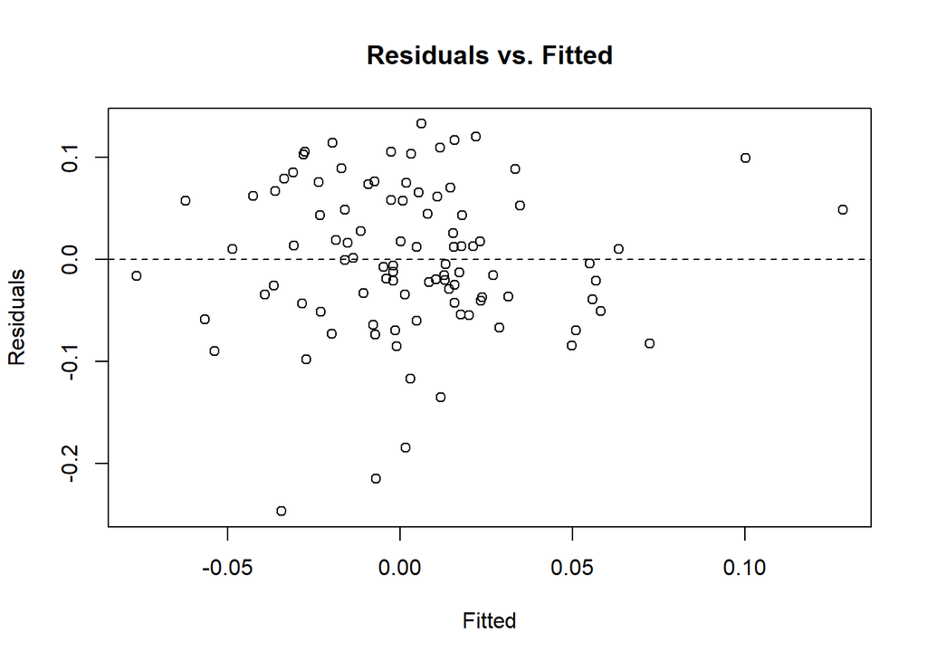

```r
plot(fitted(m_full), resid(m_full),
     xlab = "Fitted", ylab = "Residuals", main = "Residuals vs. Fitted")
abline(h = 0, lty = 2)
```

```r
bptest(m_full)
```

```
##
##  studentized Breusch-Pagan test
##
## data:  m_full
## BP = 7.3247, df = 9, p-value = 0.6034
```

- Residuals vs. Fitted Plot: The residuals are evenly distributed around the horizontal zero reference line without exhibiting a clear fan, funnel, or non-linear systematic pattern, suggesting constant error variance across predicted values.
- Breusch-Pagan Test: Yields a test statistic of $\text{BP} = 7.3247$ ($df = 9, p = 0.6034$). Because the $p$-value significantly exceeds the standard significance level ($\alpha = 0.05$), we fail to reject the null hypothesis of homoskedasticity.
- Diagnostic Implication: The baseline regression model satisfies the constant variance assumption. However, to guard against potential small-sample heteroskedasticity or leverage points, heteroskedasticity-consistent standard errors (HC3) are formally evaluated in Section 6.

## Autocorrelation

In time-series regression models of financial returns, error terms may exhibit serial dependency ($Cov(\varepsilon_t, \varepsilon_{t-s}) \neq 0$). Autocorrelation violates classical OLS assumptions; while point estimates ($\hat{\beta}$) remain unbiased, standard errors can become biased, leading to invalid $t$-tests and $F$-tests. To test for serial correlation in model residuals, we apply the Durbin-Watson test for first-order autocorrelation ($AR(1)$) and the Breusch-Godfrey test for higher-order autocorrelation up to lag 2 ($AR(2)$).

```r
dwtest(m_full)
```

```
##
##  Durbin-Watson test
##
## data:  m_full
## DW = 2.3215, p-value = 0.8845
## alternative hypothesis: true autocorrelation is greater than 0
```

```r
bgtest(m_full, order = 2)
```

```
##
##  Breusch-Godfrey test for serial correlation of order up to 2
##
## data:  m_full
## LM test = 9.2642, df = 2, p-value = 0.009734
```

## Outliers/Influential Observations

To detect influential data points that could disproportionately alter the regression slope estimates, Cook’s Distance was calculated for all $n = 96$ monthly observations. Cook’s Distance quantifies the aggregate shift in fitted values when the $i$-th observation is omitted from the dataset, combining the effects of leverage and standardized residuals:

$$\begin{aligned}
D_i
&= \frac{e_i^{*2}}{p + 1} \left( \frac{h_{ii}}{1 - h_{ii}} \right)
\\[6pt]
&\text{Where:} \\
&D_i = \text{Cook's Distance for observation } i, \\
&e_i^* = \text{standardized residual for observation } i, \\
&p = \text{number of predictor variables (regressors),} \\
&h_{ii} = \text{leverage value for observation } i.
\end{aligned}$$

where $p = 9$ represents the number of predictors in the full baseline model. Observations exceeding the conventional threshold of $4/n$ (here, $4/96 \approx 0.0417$) were flagged for inspection.

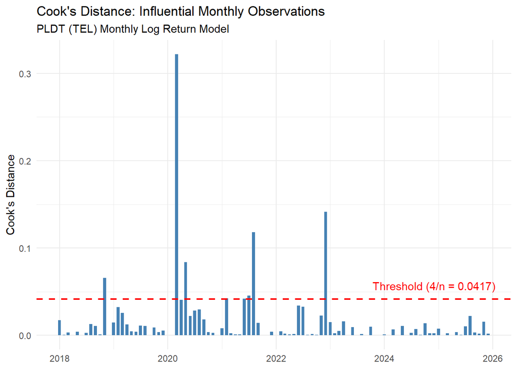

```r
full_data_diag <- model.frame(m_full) |>
  mutate(
    month = full_data$month[!is.na(full_data$PH_Manufacturing_Production)],
    cooks_d = cooks.distance(m_full),
    leverage = hatvalues(m_full),
    std_resid = rstandard(m_full))

n <- nrow(full_data_diag)
cutoff <- 4/n

ggplot(full_data_diag, aes(x = month, y = cooks_d)) + geom_bar(stat = "identity", fill = "steelblue", width = 20) +
  geom_hline(yintercept = cutoff, color = "red", linetype = "dashed", linewidth = 0.8) +
  annotate("text", x = max(full_data_diag$month) - months(12), y = cutoff + 0.015, label = paste("Threshold (4/n = ", round(cutoff, 4),
  ")", sep = ""), color = "red") +
  labs(
    title = "Cook's Distance: Influential Monthly Observations",
    subtitle = "PLDT (TEL) Monthly Log Return Model",
    x = NULL,
    y = "Cook's Distance") +
  theme_minimal()
```

```r
influential_table <- full_data_diag |>
  filter(cooks_d > cutoff) |>
  dplyr::select(month, PLDT, PSEi, USD_PHP, cooks_d, leverage) |>
  arrange(desc(cooks_d)) |>
  mutate(across(where(is.numeric), ~ round(., 4)))

knitr::kable(
  influential_table,
  caption = "Table: Observations Exceeding Cook's Distance Threshold (4/n)")
```

Table: Observations Exceeding Cook’s Distance Threshold (4/n)

| month | PLDT | PSEi | USD_PHP | cooks_d | leverage |
| --- | --- | --- | --- | --- | --- |
| 2020-03-01 | 0.1214 | -0.2434 | 0.0021 | 0.3220 | 0.5314 |
| 2022-12-01 | -0.2811 | -0.0321 | -0.0120 | 0.1415 | 0.1078 |
| 2021-08-01 | 0.1995 | 0.0892 | -0.0060 | 0.1182 | 0.3214 |
| 2020-05-01 | -0.0099 | 0.0239 | 0.0027 | 0.0838 | 0.3267 |
| 2018-11-01 | -0.1826 | 0.0314 | -0.0188 | 0.0658 | 0.0930 |
| 2021-07-01 | -0.0346 | -0.0960 | 0.0364 | 0.0454 | 0.3616 |
| 2021-02-01 | -0.1137 | 0.0272 | 0.0107 | 0.0422 | 0.1348 |
| 2021-06-01 | -0.0346 | 0.0404 | 0.0133 | 0.0418 | 0.2121 |

- Bar Plot Interpretation: As illustrated in the Cook’s Distance plot, the majority of monthly observations lie comfortably below the $4/n = 0.0417$ threshold line, indicating strong overall model stability across the sample period.
- Flagged Observations: A small subset of observations exceeds the threshold, reflecting distinct historical periods of heightened macroeconomic or corporate volatility.
- Sensitivity Strategy: Rather than automatically dropping these valid historical data points, sensitivity testing via Huber M-estimation (Robust Linear Modeling) is performed in Section 6 to confirm that coefficient directions and magnitudes remain stable when extreme leverage points are downweighted.

# 6. Model Improvements

To evaluate model stability and address potential violations of standard OLS assumptions, such as heteroskedasticity, autocorrelation, redundant predictors, and heavy-tailed outliers, four distinct model improvements were estimated alongside the baseline Initial OLS model

```r
m_step <- MASS::stepAIC(m_full, direction = "both", trace = FALSE) # Stepwise Model Selection

vcov_hc3 <- sandwich::vcovHC(m_full, type = "HC3") # HC3 Robust Standard Errors
vcov_hac <- sandwich::NeweyWest(m_full, lag = 2, prewhite = FALSE) # Newey-West HAC Standard Errors
m_robust <- MASS::rlm(
  PLDT ~ PSEi + PH_CPI + USD_PHP + BSP_RRP_Rate + PH_10Y_GS_Yield +
    PH_M3 + PH_OFW_Remittances + PH_Manufacturing_Production + VIX,
  data = full_data) # Huber M-Estimator Robust Regression

modelsummary::modelsummary(
  list(
    "Initial OLS"          = m_full,
    "OLS (HC3 Robust)"     = m_full,
    "OLS (Newey-West HAC)" = m_full,
    "Stepwise AIC"         = m_step,
    "Huber Robust (RLM)"   = m_robust),
  vcov = list(NULL, vcov_hc3, vcov_hac, NULL, NULL),
  stars = TRUE,
  gof_omit = "Log.Lik|RMSE",
  title = "Table 5.1: Model Comparison — Initial OLS, Robust Standard Errors, Stepwise Model, and Huber RLM")
```

Table 5.1: Model Comparison — Initial OLS, Robust Standard Errors, Stepwise Model, and Huber RLM

|  | Initial OLS | OLS (HC3 Robust) | OLS (Newey-West HAC) | Stepwise AIC | Huber Robust (RLM) |
| --- | --- | --- | --- | --- | --- |
| (Intercept) | -0.012 | -0.012 | -0.012 | 0.014 | -0.014 |
|  | (0.039) | (0.045) | (0.031) | (0.009) | (0.038) |
| PSEi | 0.329+ | 0.329 | 0.329 | 0.343* | 0.203 |
|  | (0.182) | (0.253) | (0.209) | (0.150) | (0.176) |
| PH_CPI | 0.001 | 0.001 | 0.001 |  | 0.003 |
|  | (0.006) | (0.006) | (0.004) |  | (0.006) |
| USD_PHP | -0.559 | -0.559 | -0.559 |  | -0.957 |
|  | (0.603) | (0.723) | (0.601) |  | (0.584) |
| BSP_RRP_Rate | -0.079 | -0.079 | -0.079+ | -0.074* | -0.065 |
|  | (0.050) | (0.054) | (0.045) | (0.035) | (0.049) |
| PH_10Y_GS_Yield | 0.009 | 0.009 | 0.009 |  | -0.001 |
|  | (0.022) | (0.026) | (0.021) |  | (0.021) |
| PH_M3 | -0.001 | -0.001 | -0.001 |  | -0.001 |
|  | (0.002) | (0.002) | (0.001) |  | (0.002) |
| PH_OFW_Remittances | -0.003 | -0.003 | -0.003* | -0.003+ | -0.003 |
|  | (0.002) | (0.002) | (0.002) | (0.002) | (0.002) |
| PH_Manufacturing_Production | 0.000 | 0.000 | 0.000* | 0.000 | 0.000 |
|  | (0.000) | (0.000) | (0.000) | (0.000) | (0.000) |
| VIX | 0.001 | 0.001 | 0.001 |  | 0.001 |
|  | (0.001) | (0.002) | (0.001) |  | (0.001) |
| Num.Obs. | 96 | 96 | 96 | 96 | 96 |
| R2 | 0.168 | 0.168 | 0.168 | 0.142 |  |
| R2 Adj. | 0.081 | 0.081 | 0.081 | 0.104 |  |
| AIC | -210.2 | -210.2 | -210.2 | -217.2 | -208.3 |
| BIC | -182.0 | -182.0 | -182.0 | -201.9 | -180.1 |
| F | 1.925 |  |  | 3.751 | 1.815 |
| Std.Errors |  | Custom | Custom |  |  |

+ p < 0.1, * p < 0.05, ** p < 0.01, *** p < 0.001

### OLS with HC3 Robust Standard Errors

- Description: Recalculates the variance of the covariance matrix using the HC3 jackknife estimator without modifying OLS coefficient point estimates.
- Primary Goal: Correct for heteroskedasticity and guard against small-sample leverage bias.
- Findings: Standard errors for key variables expand, attenuating its marginal statistical significance ($p < 0.10$) and indicating that unadjusted standard OLS slightly understated parameter variance.

### OLS with Newey-West HAC Standard Errors

- Description: Modifies the covariance structure to account simultaneously for unknown heteroskedasticity and autocorrelation across time lags (lag length = 2).
- Primary Goal: Address serial correlation in time-series residuals, preventing artificially deflated standard errors and inflated Type I error rates.
- Findings: OLS slope coefficients remain identical under Newey-West by construction. Adjusting for time-series residual dependencies modestly reduces the unrounded standard errors for PH_OFW_Remittances ($\beta = -0.003, p < 0.05$) and PH_Manufacturing_Production ($\beta = 0.000, p < 0.05$), bringing both to statistical significance. Although standard errors appear visually identical in Table 5.1 due to three-decimal rounding (0.002) and (0.000), the underlying $t$-statistics increase, demonstrating that serial correlation previously inflated standard errors in unadjusted OLS.

### Stepwise Selection

- Description: An automated variable selection procedure using backward/forward search that iteratively removes predictors failing to contribute sufficient explanatory power relative to model complexity penalization.
- Primary Goal: Mitigate overfitting and multicollinearity, drop uninformative noise, and optimize model parsimony.
- Findings: Drops five redundant regressors (PH_CPI, USD_PHP, PH_10Y_GS_Yield, PH_M3, and VIX), yielding a parsimonious four-variable specification (PSEi, BSP_RRP_Rate, PH_OFW_Remittances, and PH_Manufacturing_Production). The Stepwise model maximizes Adjusted $R^2$ ($0.104$ vs. $0.081$), achieves the lowest information criteria ($\text{AIC} = -217.2$; $\text{BIC} = -201.9$), and delivers a statistically significant overall fit ($F = 3.751, p < 0.05$). Both PSEi ($\beta = 0.343, p < 0.05$) and BSP_RRP_Rate ($\beta = -0.074, p < 0.05$) emerge as statistically significant.

# 7. Advanced Regression

### Huber Robust Linear Model

- Description: Fits the linear model via Huber M-estimation, applying quadratic loss to small residuals and linear loss to large residuals.
- Primary Goal: Reduce sensitivity to influential outliers and heavy-tailed residuals without discarding observations.
- Findings: Parameter estimates retain their directional signs relative to baseline OLS estimates (e.g., BSP_RRP_Rate at $-0.065$ and PH_OFW_Remittances at $-0.003$), confirming that extreme market leverage points do not distort the underlying directional relationships, the USD_PHP coefficient becomes more negative (-0.957) without reaching significance.Huber estimation lowers the PSEi coefficient from 0.329 to 0.203, so the estimated market beta is sensitive to the influential months. No macro variable becomes clearly significant after down-weighting, so the main findings remain unchanged.

### Huber Robust Regression (RLM)

Huber regression minimizes a loss function that is quadratic for small residuals but linear for large ones, so extreme observations receive less weight than in OLS. We estimate it with `MASS::rlm()` using the nine regressors of `m_full`.

```r
m_huber <- rlm(
  PLDT ~ PSEi + PH_CPI + USD_PHP + BSP_RRP_Rate + PH_10Y_GS_Yield +
    PH_M3 + PH_OFW_Remittances + PH_Manufacturing_Production + VIX,
  data = full_data,
  psi = psi.huber,
  maxit = 100
)

hub <- summary(m_huber)$coefficients
hub_tab <- data.frame(
  Estimate = hub[, "Value"],
  SE       = hub[, "Std. Error"],
  t        = hub[, "t value"],
  p        = 2 * pt(abs(hub[, "t value"]),
                    df = nobs(m_huber) - length(coef(m_huber)),
                    lower.tail = FALSE)
)
round(hub_tab, 4)
```

```
##                             Estimate     SE       t      p
## (Intercept)                  -0.0139 0.0375 -0.3698 0.7124
## PSEi                          0.2026 0.1761  1.1508 0.2530
## PH_CPI                        0.0029 0.0060  0.4850 0.6289
## USD_PHP                      -0.9572 0.5836 -1.6403 0.1046
## BSP_RRP_Rate                 -0.0646 0.0488 -1.3247 0.1888
## PH_10Y_GS_Yield              -0.0006 0.0211 -0.0291 0.9769
## PH_M3                        -0.0008 0.0016 -0.5102 0.6112
## PH_OFW_Remittances           -0.0029 0.0019 -1.4964 0.1382
## PH_Manufacturing_Production   0.0001 0.0001  1.5594 0.1226
## VIX                           0.0013 0.0013  0.9908 0.3246
```

The Huber fit lowers the PSEi coefficient from 0.329 to 0.203 (SE 0.176, p = 0.253), a decline of around 38%. The estimated market beta is therefore sensitive to the influential months, and its range across the two estimators is 0.20 to 0.33. The USD_PHP coefficient becomes more negative (-0.957, p = 0.105), which matches the expected sign and comes closer to significance but does not reach the 10% level. The BSP policy rate (-0.065), OFW remittances (-0.003), and manufacturing production (0.000) keep their signs and remain insignificant (p = 0.189, 0.138, and 0.123). PH_10Y_GS_Yield changes sign (+0.009 to -0.001), but its coefficient is essentially zero under both estimators. No regressor is significant at the 10% level under Huber.

```r
full_data$huber_w <- m_huber$w
full_data |>
  dplyr::filter(month %in% as.Date(c("2020-03-01","2022-12-01","2021-08-01",
                                     "2020-05-01","2018-11-01","2021-07-01",
                                     "2021-02-01","2021-06-01"))) |>
  dplyr::select(month, PLDT, PSEi, huber_w) |>
  dplyr::arrange(huber_w)
```

```
## # A tibble: 8 × 4
##   month          PLDT    PSEi huber_w
##   <date>        <dbl>   <dbl>   <dbl>
## 1 2022-12-01 -0.281   -0.0321   0.343
## 2 2018-11-01 -0.183    0.0314   0.455
## 3 2021-08-01  0.200    0.0892   0.870
## 4 2021-02-01 -0.114    0.0272   0.906
## 5 2020-03-01  0.121   -0.243    1
## 6 2020-05-01 -0.00988  0.0239   1
## 7 2021-06-01 -0.0346   0.0404   1
## 8 2021-07-01 -0.0346  -0.0960   1
```

Down-weighting the large-residual months lowers the market beta and does not make any macro variable clearly significant. The main conclusions still hold, the market coefficient is positive but imprecise, and the macro variables are not reliably different from zero. We do not claim that the estimates are insensitive to the extreme months, since the change in the PSEi coefficient shows that they are not.

```r
modelsummary(
  list("OLS" = m_full, "Huber (RLM)" = m_huber),
  stars = c('+' = .1, '*' = .05, '**' = .01, '***' = .001),
  gof_omit = "IC|Log|RMSE"
)
```

|  | OLS | Huber (RLM) |
| --- | --- | --- |
| (Intercept) | -0.012 | -0.014 |
|  | (0.039) | (0.038) |
| PSEi | 0.329+ | 0.203 |
|  | (0.182) | (0.176) |
| PH_CPI | 0.001 | 0.003 |
|  | (0.006) | (0.006) |
| USD_PHP | -0.559 | -0.957 |
|  | (0.603) | (0.584) |
| BSP_RRP_Rate | -0.079 | -0.065 |
|  | (0.050) | (0.049) |
| PH_10Y_GS_Yield | 0.009 | -0.001 |
|  | (0.022) | (0.021) |
| PH_M3 | -0.001 | -0.001 |
|  | (0.002) | (0.002) |
| PH_OFW_Remittances | -0.003 | -0.003 |
|  | (0.002) | (0.002) |
| PH_Manufacturing_Production | 0.000 | 0.000 |
|  | (0.000) | (0.000) |
| VIX | 0.001 | 0.001 |
|  | (0.001) | (0.001) |
| Num.Obs. | 96 | 96 |
| R2 | 0.168 |  |
| R2 Adj. | 0.081 |  |
| F | 1.925 | 1.815 |

+ p < 0.1, * p < 0.05, ** p < 0.01, *** p < 0.001

### Regime Interaction: PSEi × High VIX

A defensive stock such as PLDT may have a different market beta in stressful periods. We test this with an interaction:

$$\begin{aligned}
PLDT = \beta_0 + \beta_1\, \text{PSEi} + \beta_2\, \text{HIGH\_VIX} +
\beta_3\, \text{(PSEi x HIGH\_VIX)} + \varepsilon_i\\[6pt]
\end{aligned}$$

Where HIGH_VIX equals 1 when the monthly average VIX is above its sample median and 0 otherwise. The coefficient $β_1$ is the beta in calmer months, and $β_1$ + $β_3$ is the beta in high-VIX months. We estimate the model by OLS and report HC3 standard errors.

```r
full_data$HIGH_VIX <- as.numeric(full_data$VIX > median(full_data$VIX))
m_int <- lm(PLDT ~ PSEi * HIGH_VIX, data = full_data)
coeftest(m_int, vcov = sandwich::vcovHC(m_int, type = "HC3"))
```

```
##
## t test of coefficients:
##
##                  Estimate  Std. Error t value Pr(>|t|)
## (Intercept)    0.00039732  0.01034823  0.0384   0.9695
## PSEi           0.61858151  0.28062309  2.2043   0.0300 *
## HIGH_VIX       0.00909872  0.01653769  0.5502   0.5835
## PSEi:HIGH_VIX -0.42551659  0.47816516 -0.8899   0.3758
## ---
## Signif. codes:  0 '***' 0.001 '**' 0.01 '*' 0.05 '.' 0.1 ' ' 1
```

In less volatile months, the PSEi coefficient is 0.619 (p = 0.030) which is significant at 5%. The interaction coefficient is -0.426 (p = 0.376), so the implied beta in high-VIX months is about 0.19 (0.619 - 0.426). The direction is consistent with defensive behavior, since PLDT co-moves less with the market under stress, but the difference between regimes is not statistically significant, so the data cannot distinguish the two betas. The HIGH_VIX main effect (0.009, p = 0.584) is also insignificant.

This model contains only PSEi and the regime terms, so its calm-month beta (0.62) is not comparable with the full model’s 0.33. Next, a median split leaves about 48 months in each regime, which limits power, the regime result is therefore weak. This suggests that PLDT’s beta may be lower in stress.

# 8. Financial Interpretation

As a small disclaimer, these recommendations are not to be directly taken as investment advice, but rather presenting our academic framing of findings and regression evidence through the project.

### Summary

PLDT’s monthly returns are positively associated with the local market, with a beta of about 0.33, 95% interval at about -0.03 to 0.69, and Huber 0.20. Domestic macro variables do not add much statistically reliable explanatory power as a group (p = 0.15), and the significance of individual variables depends on the standard error estimation. Currently, even the best models leave most of the return variation unexplained, with R2 at most 17% and 4.7% for the market-only model.

### Recommendation

- Don’t rely on the domestic macroeconomic variables to explain or anticipate TEL’s monthly returns. Under the initial OLS, none of them is individually significant at 5%. As a group they are not jointly significant either (F = 1.5559, p =0.1502), and the macro-only model is not significant overall (F = 1.711, adjusted R² = 0.056)
- Treat the few macro results that do become significant with caution. Under Newey-West standard errors, OFW remittances (p = 0.0442) and manufacturing production (p = 0.0414) cross the 5% level. However, their coefficients are very small (−0.0032 and 0.0001), the result does not appear under the initial OLS or HC3 estimates, and manufacturing growth contains extreme pandemic era base-effect values (−82% to +534%).
- Use the local market as the main reference point for TEL. PSEi is the only variable with a consistently positive association (β ≈ 0.33 in the market-only and full models, 0.20 under Huber), suggesting TEL has moved less than the market. The market-only model also has the lowest BIC (−205.5). This relationship should not be overstated, since PSEi is not significant under HC3 or Newey-West standard errors (Table 5.1).
- Pair any market-based view with company-specific information such as earnings, capital expenditure, and dividend announcements. Large residuals in months like December 2022 show that events specific to the company are not captured by the macro variables.

### Limitations

**Low explanatory power**

The full model explains only 16.8% of the variation (adjusted R² = 0.081), so most of TEL’s returns are driven by factors outside the model, such as earnings, dividends, and competition.

**Sample Size and period**

The data has 96 monthly observations for nine regressors, and covers COVID-19 and the 2022 capex-overrun episode. Eight months exceed the Cook’s distance threshold, so a few events shape the estimates.

**Dependent variable construction**

PLDT returns are built from the NYSE-listed ADR (PHI) converted into pesos, not from TEL’s PSE price. Differences in trading hours may weaken the measured link to the PSEi. The return also includes the USD/PHP change by construction, so its relationship with the USD_PHP regressor is partly mechanical.

**Sensitivity to estimation method**

Significance changes with the standard errors used (OFW and manufacturing under Newey-West only, PSEi under classical OLS only). The stepwise model was also selected using the same 96 observations it is evaluated on, so its fit is likely overstated.

**Scope of the model**

The model is linear and contemporaneous, with no lags or nonlinearities, and its results show association and not causation.

### Conclusion

This study examined whether domestic macroeconomic conditions help explain PLDT’s monthly stock returns beyond the movement of the Philippine stock market. The results suggest that, for the most part, they do not. PSEi is the only variable with a consistent positive association (about 0.33), the macro variables are not jointly significant, and even the best specification explains at most 16.8% of the variation in returns. Diagnostics found no multicollinearity or heteroskedasticity, but did find autocorrelation and eight influential months, so robust and HAC estimates were used to check the results.

Overall, PLDT’s monthly reuters appear to depend more on market-wide movements and factors outside this model than on domestic macroeconomic conditions. Future work could add company fundamentals, lagged variables, and a longer sample, and use TEL’s PSE price directly.